# **ABSTRACT**

In today's Information Technology driven world, data coupled with more focus on Support processess has created oppourtunities for business innovation with the help of Cognitive computing techniques that aid to implement robust and enterprise centric automation. These automation's were intended to improve productivity across multiple functions and the key to such automations is human brain simulation that use the experience of the past and use that knowledge to make structued and informed business decisions.

Natural language processing is one of the main abilities of a cognitive computing system which can process the language we use and convert the text to structured data. Such a attempt is not easy to reach and involve lot of data analyzing\processing which is a complex and resource-intensive task. A huge amount of information is hidden within textual data repositories under the guise of emails, documents, chats, etc., An attempt to unwrap the hidden information can help organizations to develop better and reliable business strategies. While these techniques have wide spread applications in various business domains, problem solving besides reducing the administrative tasks are a key application.

In an Information Technology setup, IT service management(ITSM) plays an important role and is characterized by adopting a process approach towards management, focusing on customer needs and IT services for customers rather than IT systems. Incident Management, a focus area under ITSM deal with the incident tickets created by various stakes of the organization with a primary goal to resolve an issue\bring back normalcy as quickly as possible. Whenever an incident is created, it reaches the Service desk team where the issue would be analyzed with the available preliminary information and then it gets routed to the respective teams\group of the business function to resolve the issue. While the preliminary manual analysis of issue details is resource intensive and prone to human error in which case may cause further delay in issue resolution and defeat the purpose of ITSM.

Advanacements in Congnitive computing systems came to the rescue of business organizations where processes are being reviewed, automated where possible to reduce the effective cost to organization which is a key business driver in current situation.

Current study is focussed in identiying the business problem in Incident Management\Support Ticket Management and based on the business drivers, built a solution which would automate ticket assignment by leveraging the NLP tech enablers.

# **INTRODUCTION**

In an support setup, incidents raised by various internal and external stakes were analyzed by L1 and L2 Support teams based on the incident description or available details shared by the ticket creator and resolution provided or escalated further by means of ticket assignment to teams specialized in dealing with specific problems for quick resolution of the incidents. At the outset, not all incidents created were alike due to the fact that the extent of information a specific incident may carry may be limited or not easily understood to be processed although the resolution may be the same. The first step to quick incident resolution is right ticket assignment to the team of engineers who are equipped or proficient in dealing a specific category of issues that fall under their scope. While the correct ticket assignment can help reduce the operational cost noticably and also help use the valuable resources on more productive work to improve the overall service experiance.

Below is the **Current Incident Management Process** -

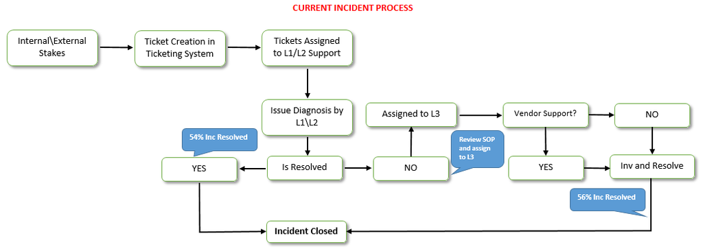

# **BUSINESS PROBLEM**

Above current process reveal that incidents are created by various stakeholders and are assigned to Service Desk teams (L1 / L2 teams). This team will review the incidents for right ticket categorization, priorities and then carry out initial diagnosis to see if they can resolve. Around ~54% of the incidents are resolved by L1 / L2 teams. Incase L1 / L2 is unable to resolve, they will then escalate / assign the tickets to L3 teams after reviewing Standard Operating Procedures (SOPs) which is time consuming and ~25-30% of incidents needs to be reviewed for SOPs before ticket assignment. At the same time, not every instance of ticket assignment by L1/L2 teams are accurate and ~25% of incidents are wrongly assigned to functional teams. L3 teams will carry out detailed diagnosis and resolves the incidents. Around ~56% of incidents are resolved by Functional / L3 teams. Incase, vendor support is needed, they will reach out for their support towards incident closure. As the ticket assignment process is manual, instances of unattended or timely action on incidents raised by stake holders degrade the effectiveness of the support eco system.

# **SOLUTION**

The solution to the Business Problem is the Proposed Incident Management process where the current incident creation step shall remain as-is and are fed to the Cognitive techniques like NLP aided by Machine Learning Algorithms where the details of the incidents were analyzed by the models and classification of the incidents were performed based on prior experience. The output from the Machine Learning model will be the predicted Classification group or the Support Group responsible for solving similar incidents in the past. Based on the output of the models, the incident shall be assigned to respective Assignment Group as classified by the Machine Learning model. Post ticket assignment, the issue resolution step can remain as-is.

**Proposed Incident Management Process** -

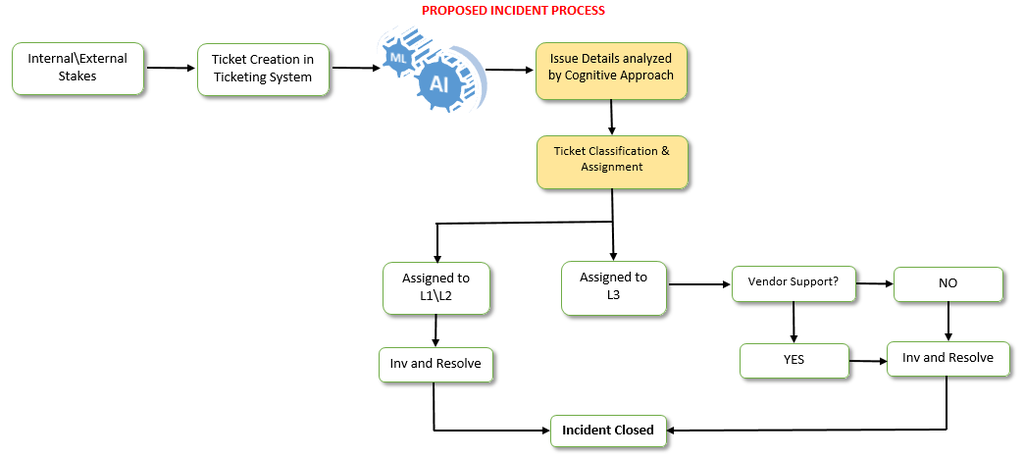

```python
## Details about the data and dataset files are given in below link,
## https://drive.google.com/open?id=1OZNJm81JXucV3HmZroMq6qCT2m7ez7IJ
```

```python
# Installing the necessary Packages
!pip install -q nltk
!pip install -q spacy
!pip install -q pycountry
!pip install -q fasttext
!pip install -q googletrans
!pip install -q google_trans_new
!pip install -q ftfy
!pip install -q fuzzywuzzy
```

```python
#Tokenizing the import file
import requests

def download_file_from_google_drive(id, destination):
    URL = "https://docs.google.com/uc?export=download"

    session = requests.Session()

    response = session.get(URL, params = { 'id' : id }, stream = True)
    token = get_confirm_token(response)

    if token:
        params = { 'id' : id, 'confirm' : token }
        response = session.get(URL, params = params, stream = True)

    save_response_content(response, destination)

def get_confirm_token(response):
    for key, value in response.cookies.items():
        if key.startswith('download_warning'):
            return value

    return None

def save_response_content(response, destination):
    CHUNK_SIZE = 32768

    with open(destination, "wb") as f:
        for chunk in response.iter_content(CHUNK_SIZE):
            if chunk: # filter out keep-alive new chunks
                f.write(chunk)
```

```python
#Details of files to be imported
file_id = '1OZNJm81JXucV3HmZroMq6qCT2m7ez7IJ'
destination = 'IT_Ticket_Classification.xlsx'
download_file_from_google_drive(file_id, destination)
```

```python
# Reading the data file from G drive and checking the top 5 data points
import pandas as pd
import numpy as np
import sys
#Set your file name
file_name ='IT_Ticket_Classification.xlsx'

Dataframe=pd.read_excel(file_name)
Dataframe.head()
```

|  | Short description | Description | Caller | Assignment group |
| --- | --- | --- | --- | --- |
| 0 | login issue | -verified user details.(employee# & manager na... | spxjnwir pjlcoqds | GRP_0 |
| 1 | outlook | \r\n\r\nreceived from: hmjdrvpb.komuaywn@gmail... | hmjdrvpb komuaywn | GRP_0 |
| 2 | cant log in to vpn | \r\n\r\nreceived from: eylqgodm.ybqkwiam@gmail... | eylqgodm ybqkwiam | GRP_0 |
| 3 | unable to access hr_tool page | unable to access hr_tool page | xbkucsvz gcpydteq | GRP_0 |
| 4 | skype error | skype error | owlgqjme qhcozdfx | GRP_0 |

```python
# Checking the count of unique caller values in the Dataframe
callers = Dataframe['Caller'].unique()
callers.shape
```

```
(2950,)
```

```python
# Checking the characteristics of the data holistically
Dataframe.info()
```

```
<class 'pandas.core.frame.DataFrame'>
RangeIndex: 8500 entries, 0 to 8499
Data columns (total 4 columns):
 #   Column             Non-Null Count  Dtype
---  ------             --------------  -----
 0   Short description  8492 non-null   object
 1   Description        8499 non-null   object
 2   Caller             8500 non-null   object
 3   Assignment group   8500 non-null   object
dtypes: object(4)
memory usage: 265.8+ KB
```

Looks like out of the total data points of 8500, few blank values\NULL values are evident in Short Description and Description and hoping that for a given data point either of them are not NULL.

```python
# Checking the data distribution in the target column(Assigned Group)
Group_info=Dataframe['Assignment group'].value_counts()
Group_info.describe()
```

```
count      74.000000
mean      114.864865
std       465.747516
min         1.000000
25%         5.250000
50%        26.000000
75%        84.000000
max      3976.000000
Name: Assignment group, dtype: float64
```

Data spread in the Target class distrubtion is extremely skewed with some group with some group counting to 3976(appx ~50% of the data). At the same time, Lowest count in a given group is 1 record. We may potentially mark up data in groups with very low counts to reduce group imbalance.

```python
# Checking the Groups with less than 100 data points
data = Dataframe.groupby(['Assignment group'])
regroup=[]
for grp in Dataframe['Assignment group'].unique():
  if(data.get_group(grp).shape[0]<100):
    regroup.append(grp)
print('Found {} groups which have under 100 samples'.format(len(regroup)))
# Total Groups
n = len(pd.unique(Dataframe['Assignment group']))
print("Total groups count  :",  n)
# Unique Groups check
Dataframe['Assignment group'].unique()
```

```
Found 58 groups which have under 100 samples
Total groups count  : 74
```

```
array(['GRP_0', 'GRP_1', 'GRP_3', 'GRP_4', 'GRP_5', 'GRP_6', 'GRP_7',
       'GRP_8', 'GRP_9', 'GRP_10', 'GRP_11', 'GRP_12', 'GRP_13', 'GRP_14',
       'GRP_15', 'GRP_16', 'GRP_17', 'GRP_18', 'GRP_19', 'GRP_2',
       'GRP_20', 'GRP_21', 'GRP_22', 'GRP_23', 'GRP_24', 'GRP_25',
       'GRP_26', 'GRP_27', 'GRP_28', 'GRP_29', 'GRP_30', 'GRP_31',
       'GRP_33', 'GRP_34', 'GRP_35', 'GRP_36', 'GRP_37', 'GRP_38',
       'GRP_39', 'GRP_40', 'GRP_41', 'GRP_42', 'GRP_43', 'GRP_44',
       'GRP_45', 'GRP_46', 'GRP_47', 'GRP_48', 'GRP_49', 'GRP_50',
       'GRP_51', 'GRP_52', 'GRP_53', 'GRP_54', 'GRP_55', 'GRP_56',
       'GRP_57', 'GRP_58', 'GRP_59', 'GRP_60', 'GRP_61', 'GRP_32',
       'GRP_62', 'GRP_63', 'GRP_64', 'GRP_65', 'GRP_66', 'GRP_67',
       'GRP_68', 'GRP_69', 'GRP_70', 'GRP_71', 'GRP_72', 'GRP_73'],
      dtype=object)
```

Of the total 74 unique target groups, 58 groups have data points less than 100.

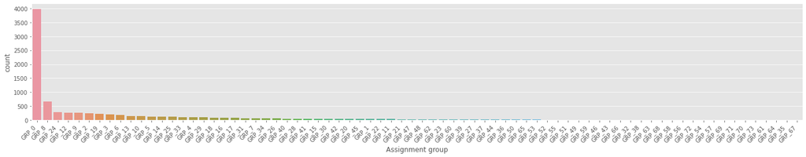

```python
# Data Distribution View
import seaborn as sns
import matplotlib.pyplot as plt
import warnings
%matplotlib inline

plt.style.use('ggplot')

descending_order = Dataframe['Assignment group'].value_counts().sort_values(ascending=False).index
plt.subplots(figsize=(20,4))
ax=sns.countplot(x='Assignment group', data=Dataframe,order=descending_order)
ax.set_xticklabels(ax.get_xticklabels(), rotation=45, ha="right")
plt.tight_layout()
plt.show()
```

Data spread Skewness is visually evident as we saw with the Describe function.

```python
# Dropping Caller Attribute as we dont need it
Dataframe_1 = Dataframe
Dataframe_1.drop(['Caller'],inplace=True,axis=1)
Dataframe_1.head()
```

|  | Short description | Description | Assignment group |
| --- | --- | --- | --- |
| 0 | login issue | -verified user details.(employee# & manager na... | GRP_0 |
| 1 | outlook | \r\n\r\nreceived from: hmjdrvpb.komuaywn@gmail... | GRP_0 |
| 2 | cant log in to vpn | \r\n\r\nreceived from: eylqgodm.ybqkwiam@gmail... | GRP_0 |
| 3 | unable to access hr_tool page | unable to access hr_tool page | GRP_0 |
| 4 | skype error | skype error | GRP_0 |

# **Preprocessing**

```python
# Let's look at the rows with null values
Dataframe_1[pd.isnull(Dataframe_1).any(axis=1)]
```

|  | Short description | Description | Assignment group |
| --- | --- | --- | --- |
| 2604 | NaN | \r\n\r\nreceived from: ohdrnswl.rezuibdt@gmail... | GRP_34 |
| 3383 | NaN | \r\n-connected to the user system using teamvi... | GRP_0 |
| 3906 | NaN | -user unable tologin to vpn.\r\n-connected to... | GRP_0 |
| 3910 | NaN | -user unable tologin to vpn.\r\n-connected to... | GRP_0 |
| 3915 | NaN | -user unable tologin to vpn.\r\n-connected to... | GRP_0 |
| 3921 | NaN | -user unable tologin to vpn.\r\n-connected to... | GRP_0 |
| 3924 | NaN | name:wvqgbdhm fwchqjor\nlanguage:\nbrowser:mic... | GRP_0 |
| 4341 | NaN | \r\n\r\nreceived from: eqmuniov.ehxkcbgj@gmail... | GRP_0 |
| 4395 | i am locked out of skype | NaN | GRP_0 |

```python
#Dropping Missing Values
Dataframe_1.dropna(inplace=True)
Dataframe_1.info()
```

```
<class 'pandas.core.frame.DataFrame'>
Int64Index: 8491 entries, 0 to 8499
Data columns (total 3 columns):
 #   Column             Non-Null Count  Dtype
---  ------             --------------  -----
 0   Short description  8491 non-null   object
 1   Description        8491 non-null   object
 2   Assignment group   8491 non-null   object
dtypes: object(3)
memory usage: 265.3+ KB
```

```python
# Creating a composite Description Attribute by concatinating Desc and Short Desc
Dataframe_1['Comb_Description'] = Dataframe_1['Short description'].astype(str) + ' ' + Dataframe_1['Description'].astype(str)
Dataframe_1.head()
```

|  | Short description | Description | Assignment group | Comb_Description |
| --- | --- | --- | --- | --- |
| 0 | login issue | -verified user details.(employee# & manager na... | GRP_0 | login issue -verified user details.(employee# ... |
| 1 | outlook | \r\n\r\nreceived from: hmjdrvpb.komuaywn@gmail... | GRP_0 | outlook \r\n\r\nreceived from: hmjdrvpb.komuay... |
| 2 | cant log in to vpn | \r\n\r\nreceived from: eylqgodm.ybqkwiam@gmail... | GRP_0 | cant log in to vpn \r\n\r\nreceived from: eylq... |
| 3 | unable to access hr_tool page | unable to access hr_tool page | GRP_0 | unable to access hr_tool page unable to access... |
| 4 | skype error | skype error | GRP_0 | skype error skype error |

```python
#check for duplicates
Dataframe_1.duplicated().sum()
```

```
588
```

```python
#remove duplicates
Dataframe_1.drop_duplicates(inplace = True)
```

```python
# Data Cleaning by removing specific words and symbols that have no meaning
from dateutil import parser
import re
import nltk
import string
import ftfy
def is_valid_date(date_str):
    try:
        parser.parse(date_str)
        return True
    except:
        return False

def clean_data(text):
    text = ftfy.fix_text(text)
    text = text.lower()
    text = ' '.join([w for w in text.split() if not is_valid_date(w)])
    text = re.sub(r"received from:",' ',text)
    text = re.sub(r"from:",' ',text)
    text = re.sub(r"to:",' ',text)
    text = re.sub(r"subject:",' ',text)
    text = re.sub(r"sent:",' ',text)
    text = re.sub(r"ic:",' ',text)
    text = re.sub(r"cc:",' ',text)
    text = re.sub(r"bcc:",' ',text)
    # Remove email
    text = re.sub(r'\S*@\S*\s?', '', text)
    # Remove numbers
    text = re.sub(r'\d+','' ,text)
    # Remove new line characters
    text = re.sub(r'\n',' ',text)
    # Remove hashtag while keeping hashtag text
    text = re.sub(r'#','', text)
    # Handle & symbol
    text = re.sub(r'&;?', 'and',text)
    # Remove HTML special entities (e.g. &amp;)
    text = re.sub(r'\&\w*;', '', text)
    #remove html tags
    text = re.sub(r'<.*?>',' ',text)
    # Remove hyperlinks
    text = re.sub(r'https?:\/\/.*\/\w*', '', text)
    #remove punctuation !"#$%&'()*+,-./:;<=>?@[\]^_`{|}~
    # insert spaces between special characters to isolate them
    PUNCT_TO_REMOVE = string.punctuation
    special_char_pattern = re.compile(r'([{.(-):/\@#$%&;<=?>_!}])')
    text = special_char_pattern.sub(" \\1 ", text)
    text = text.translate(str.maketrans('', '', PUNCT_TO_REMOVE))

    for name in callers:
      namelist = [part for part in name.split()]
      for namepart in namelist:
          text = text.replace(namepart,'')

    text = re.sub(r"\s+[a-zA-Z]\s+", ' ', text)
    #remove more than 1 space
    text = re.sub(r'\s+',' ',text)
    text = text.strip()
    return text

Dataframe_1['Comb_Description'] = Dataframe_1['Comb_Description'].apply(clean_data)
Dataframe_1.head()
```

|  | Short description | Description | Assignment group | Comb_Description |
| --- | --- | --- | --- | --- |
| 0 | login issue | -verified user details.(employee# & manager na... | GRP_0 | login issue verified user details employee and... |
| 1 | outlook | \r\n\r\nreceived from: hmjdrvpb.komuaywn@gmail... | GRP_0 | outlook hello team my meetings skype meetings ... |
| 2 | cant log in to vpn | \r\n\r\nreceived from: eylqgodm.ybqkwiam@gmail... | GRP_0 | cant log in to vpn hi cannot log on to vpn best |
| 3 | unable to access hr_tool page | unable to access hr_tool page | GRP_0 | unable to access hr tool page unable to access... |
| 4 | skype error | skype error | GRP_0 | skype error skype error |

```python
# Language Detection and Translation using pretrained model
!wget  https://dl.fbaipublicfiles.com/fasttext/supervised-models/lid.176.bin
```

```
--2021-01-07 03:54:49--  https://dl.fbaipublicfiles.com/fasttext/supervised-models/lid.176.bin
Resolving dl.fbaipublicfiles.com (dl.fbaipublicfiles.com)... 172.67.9.4, 104.22.74.142, 104.22.75.142, ...
Connecting to dl.fbaipublicfiles.com (dl.fbaipublicfiles.com)|172.67.9.4|:443... connected.
HTTP request sent, awaiting response... 200 OK
Length: 131266198 (125M) [application/octet-stream]
Saving to: ‘lid.176.bin.2’

lid.176.bin.2       100%[===================>] 125.18M  63.4MB/s    in 2.0s

2021-01-07 03:54:51 (63.4 MB/s) - ‘lid.176.bin.2’ saved [131266198/131266198]
```

```python
# Passing the Description data to the pre trained model for Language detection
import fasttext
from pycountry import languages
from google_trans_new import google_translator

PRETRAINED_MODEL_PATH = 'lid.176.bin'
model = fasttext.load_model(PRETRAINED_MODEL_PATH)
langs = []
for sent in Dataframe_1['Comb_Description']:
    lang = model.predict(sent)[0]
    lang = str(lang)[11:13]
    if lang == 'yu':
      lang='zh'
    langs.append(lang)
Dataframe_1['Language'] = langs
Dataframe_1['Language'] = Dataframe_1['Language'].apply(lambda x  : languages.get(alpha_2=x).name)
Dataframe_1.head(10)
```

|  | Short description | Description | Assignment group | Comb_Description | Language |
| --- | --- | --- | --- | --- | --- |
| 0 | login issue | -verified user details.(employee# & manager na... | GRP_0 | login issue verified user details employee and... | English |
| 1 | outlook | \r\n\r\nreceived from: hmjdrvpb.komuaywn@gmail... | GRP_0 | outlook hello team my meetings skype meetings ... | English |
| 2 | cant log in to vpn | \r\n\r\nreceived from: eylqgodm.ybqkwiam@gmail... | GRP_0 | cant log in to vpn hi cannot log on to vpn best | English |
| 3 | unable to access hr_tool page | unable to access hr_tool page | GRP_0 | unable to access hr tool page unable to access... | English |
| 4 | skype error | skype error | GRP_0 | skype error skype error | Japanese |
| 5 | unable to log in to engineering tool and skype | unable to log in to engineering tool and skype | GRP_0 | unable to log in to engineering tool and skype... | English |
| 6 | event: critical:HostName_221.company.com the v... | event: critical:HostName_221.company.com the v... | GRP_1 | event critical hostname company com the value ... | English |
| 7 | ticket_no1550391- employment status - new non-... | ticket_no1550391- employment status - new non-... | GRP_0 | ticket no employment status new nonemployee en... | English |
| 8 | unable to disable add ins on outlook | unable to disable add ins on outlook | GRP_0 | unable to disable add ins on outlook unable to... | English |
| 9 | ticket update on inplant_874773 | ticket update on inplant_874773 | GRP_0 | ticket update on inplant ticket update on inplant | English |

```python
# Detected Language Count
l = len(pd.unique(Dataframe_1['Language']))
print("Detected Language count  :",  l)
# Unique Language list
Dataframe_1['Language'].unique()
```

```
Detected Language count  : 22
```

```
array(['English', 'Japanese', 'Spanish', 'Croatian', 'Chinese', 'German',
       'Catalan', 'Javanese', 'Portuguese', 'Russian', 'Polish', 'French',
       'Finnish', 'Italian', 'Swedish', 'Turkish', 'Indonesian', 'Danish',
       'Esperanto', 'Norwegian', 'Kannada', 'Dutch'], dtype=object)
```

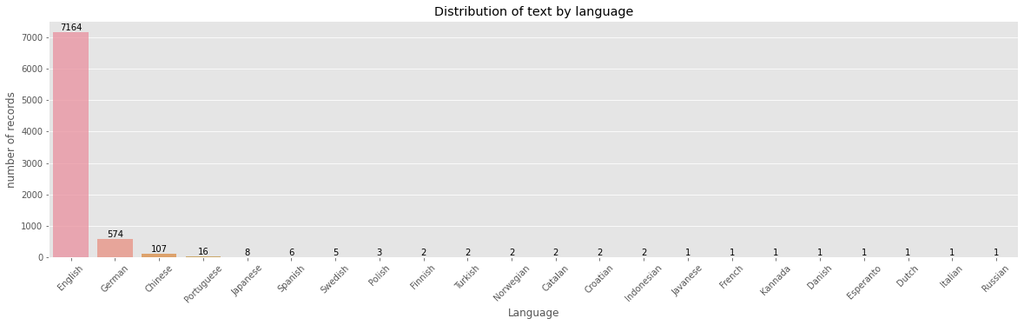

```python
#checking detected languages
x=Dataframe_1['Language'].value_counts().sort_values(ascending=False)
plt.figure(figsize=(20,5))
ax= sns.barplot(x=x.index, y=x.values, alpha=0.8, order=Dataframe_1["Language"].value_counts().index)
plt.title("Distribution of text by language")
plt.ylabel('number of records')
plt.xlabel('Language')
plt.xticks(rotation=45)
rects = ax.patches
labels = x.values
for rect, label in zip(rects, labels):
    height = rect.get_height()
    ax.text(rect.get_x() + rect.get_width()/2, height + 5, label, ha='center', va='bottom')
plt.show();
```

As evident from the above visualisation we have 22 different languages detected and most of the data is in English. We would need to translate all these into a single language (preferred English) in further steps to process.

```python
#Defining function for translation using google translator
from google_trans_new import google_translator
translator = google_translator()
def translateIfRequired(x):
    translatedText = translator.translate(x)
    return translatedText
```

```python
#Looping through the combined description data for translation
desc_trans=[]
for index, row in Dataframe_1.iterrows():
  sentence=row['Comb_Description']
  if(row['Language']!='English' and sentence !=''):
    #print(index,sentence)
    trans = translateIfRequired(sentence)
    desc_trans.append(trans)
  else:
    desc_trans.append(sentence)
```

```python
#Getting translated data in dataframe under the column Translated Description
Dataframe_1['Translated_Description']=desc_trans
Dataframe_1.head()
```

|  | Short description | Description | Assignment group | Comb_Description | Language | Translated_Description |
| --- | --- | --- | --- | --- | --- | --- |
| 0 | login issue | -verified user details.(employee# & manager na... | GRP_0 | login issue verified user details employee and... | English | login issue verified user details employee and... |
| 1 | outlook | \r\n\r\nreceived from: hmjdrvpb.komuaywn@gmail... | GRP_0 | outlook hello team my meetings skype meetings ... | English | outlook hello team my meetings skype meetings ... |
| 2 | cant log in to vpn | \r\n\r\nreceived from: eylqgodm.ybqkwiam@gmail... | GRP_0 | cant log in to vpn hi cannot log on to vpn best | English | cant log in to vpn hi cannot log on to vpn best |
| 3 | unable to access hr_tool page | unable to access hr_tool page | GRP_0 | unable to access hr tool page unable to access... | English | unable to access hr tool page unable to access... |
| 4 | skype error | skype error | GRP_0 | skype error skype error | Japanese | skype error skype error |

```python
# Stop Word Removal
from nltk.corpus import stopwords
import nltk
nltk.download('wordnet')
nltk.download('punkt')
nltk.download('stopwords')
nltk.download('averaged_perceptron_tagger')

STOPWORDS = stopwords.words('english')
STOPWORDS.extend(['yes','na','hi','hello'])
def remove_stopwords(text):
    """custom function to remove the stopwords"""
    return " ".join([word for word in str(text).split() if word not in STOPWORDS])

Dataframe_1['Translated_Description'] = Dataframe_1['Translated_Description'].apply(lambda text: remove_stopwords(text))
Dataframe_1.head()
```

|  | Short description | Description | Assignment group | Comb_Description | Language | Translated_Description |
| --- | --- | --- | --- | --- | --- | --- |
| 0 | login issue | -verified user details.(employee# & manager na... | GRP_0 | login issue verified user details employee and... | English | login issue verified user details employee man... |
| 1 | outlook | \r\n\r\nreceived from: hmjdrvpb.komuaywn@gmail... | GRP_0 | outlook hello team my meetings skype meetings ... | English | outlook team meetings skype meetings etc appea... |
| 2 | cant log in to vpn | \r\n\r\nreceived from: eylqgodm.ybqkwiam@gmail... | GRP_0 | cant log in to vpn hi cannot log on to vpn best | English | cant log vpn cannot log vpn best |
| 3 | unable to access hr_tool page | unable to access hr_tool page | GRP_0 | unable to access hr tool page unable to access... | English | unable access hr tool page unable access hr to... |
| 4 | skype error | skype error | GRP_0 | skype error skype error | Japanese | skype error skype error |

```python
# Lemitization of Text
import spacy
# Initialize spacy 'en' medium model, keeping only tagger component needed for lemmatization
nlp = spacy.load('en_core_web_sm', disable=['parser', 'ner'])

# Define a function to lemmatize the descriptions
def lemmatize_text(sentence):
    # Parse the sentence using the loaded 'en' model object `nlp`
    doc = nlp(sentence)
    return " ".join([token.lemma_ for token in doc if token.lemma_ !='-PRON-'])

Dataframe_1['Translated_Description'] = Dataframe_1['Translated_Description'].apply(lemmatize_text)
```

**Generating Word Cloud**

```python
#Function definition for generating word cloud
from wordcloud import WordCloud, STOPWORDS, ImageColorGenerator
def generate_word_cloud(corpus):
    # Instantiate the wordcloud object
    wordcloud = WordCloud(width = 800, height = 800,
                    background_color ='white',
                    stopwords=STOPWORDS,
                    # mask=mask,
                    min_font_size = 10).generate(corpus)

    # plot the WordCloud image
    plt.figure(figsize = (12, 12), facecolor = None)
    plt.imshow(wordcloud)
    plt.axis("off")
    plt.tight_layout(pad = 0)

    plt.show()
```

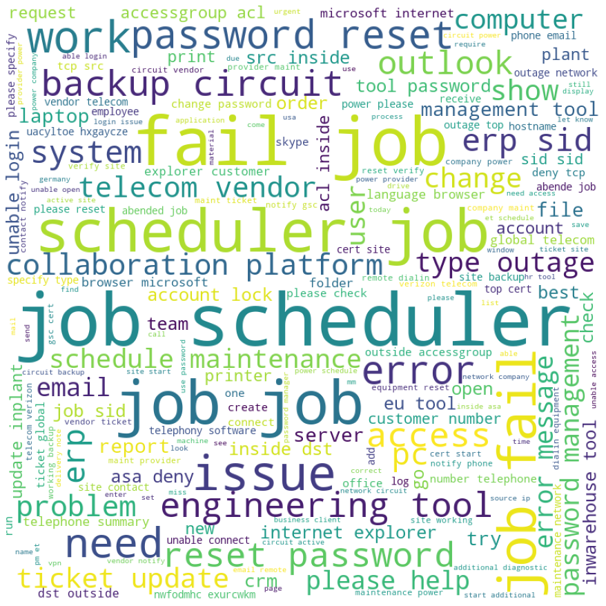

```python
# Word Cloud for all tickets assigned to Translated_Description
generate_word_cloud(' '.join(Dataframe_1.Translated_Description.str.strip()))
```

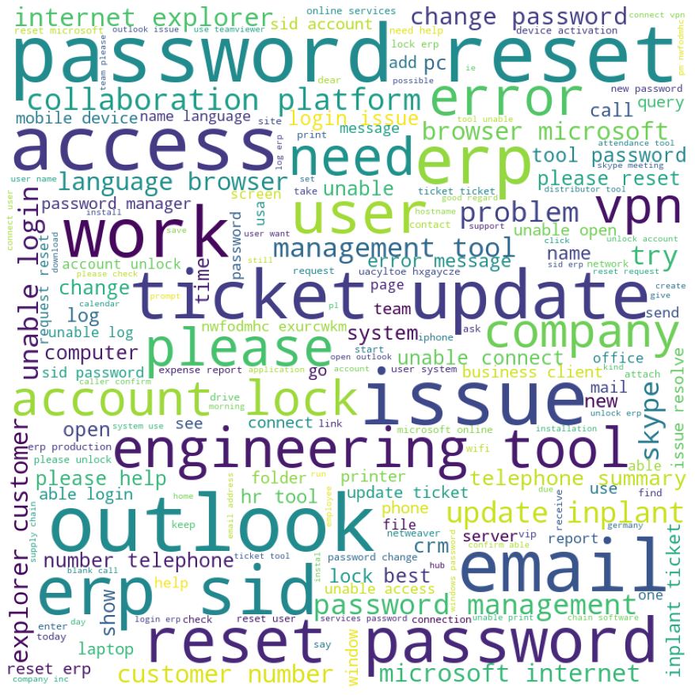

```python
# Word Cloud for all tickets assigned to GRP_0
generate_word_cloud(' '.join(Dataframe_1[Dataframe_1['Assignment group'] == 'GRP_0'].Translated_Description.str.strip()))
```

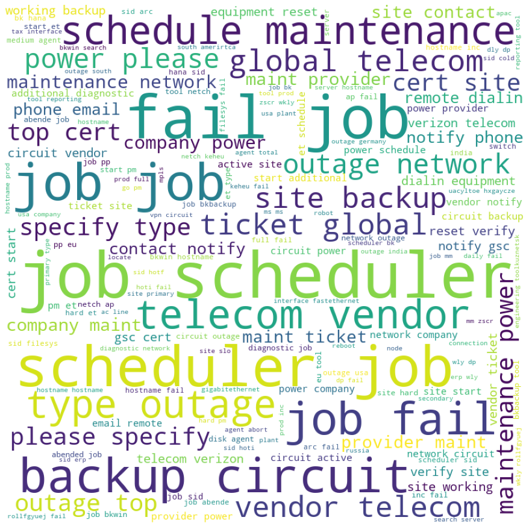

```python
# Word Cloud for all tickets assigned to GRP_8
generate_word_cloud(' '.join(Dataframe_1[Dataframe_1['Assignment group'] == 'GRP_8'].Translated_Description.str.strip()))
```

From above three word clouds we see some of the evident words in the whole groups like Scheduler, Job, telecom, fail, file, access, password.

**Identifying Similar Groups**

```python
#Getting a dataframe with only required columns and merging the translated descriptions except for group zero to find similar groups
df_temp = Dataframe_1[['Assignment group', 'Translated_Description']]
merged_desc=df_temp.groupby('Assignment group', as_index=False).agg({'Translated_Description' : ' '.join})
merged_desc = merged_desc[merged_desc['Assignment group'] != 'GRP_0']
merged_desc.head()
```

|  | Assignment group | Translated_Description |
| --- | --- | --- |
| 1 | GRP_1 | event critical hostname company com value moun... |
| 2 | GRP_10 | job hr payroll fail job scheduler job hr payro... |
| 3 | GRP_11 | engineering tool drawing original pdf format s... |
| 4 | GRP_12 | amssm label sysamssm ef server space consume s... |
| 5 | GRP_13 | job job fail job scheduler job job fail job sc... |

```python
#Defining dataframe for keeping the similarity score
grps_done=[]
grp_matches = pd.DataFrame(columns = ['Target1','Target2','Score'])
```

```python
#Initiating Fuzzy Wuzzy to get the similarity score among different groups
from fuzzywuzzy import process, fuzz
for index, rowA in merged_desc.iterrows():
    for index, rowB in merged_desc.iterrows():
      if(rowA['Assignment group'] != rowB['Assignment group'] and rowB['Assignment group'] not in grps_done):
        score = fuzz.token_set_ratio(rowA['Translated_Description'], rowB['Translated_Description'])
        data = {'Target1' : rowA['Assignment group'],'Target2':rowB['Assignment group'],'Score' : score}
        #print(data)
        grp_matches=grp_matches.append(data,ignore_index = True)
    grps_done.append(rowA['Assignment group'])
```

Filtering with matching percentage

```python
#defining the similarity percentage threshold and getting the similarity score in the predefined dataframe
matching_score_limit=80
temp_grps=grp_matches[grp_matches.Score > matching_score_limit].sort_values(by=['Score'],ascending=False)
temp_grps
```

|  | Target1 | Target2 | Score |
| --- | --- | --- | --- |
| 790 | GRP_2 | GRP_69 | 95 |
| 757 | GRP_2 | GRP_39 | 94 |
| 783 | GRP_2 | GRP_62 | 93 |
| 1395 | GRP_3 | GRP_69 | 93 |
| 2437 | GRP_57 | GRP_9 | 93 |
| ... | ... | ... | ... |
| 1098 | GRP_25 | GRP_35 | 81 |
| 394 | GRP_14 | GRP_55 | 81 |
| 715 | GRP_19 | GRP_56 | 81 |
| 767 | GRP_2 | GRP_48 | 81 |
| 1199 | GRP_27 | GRP_3 | 81 |

72 rows × 3 columns

```python
#Getting a list of common groups based out of threshold percentages for merging
grp_common = pd.DataFrame(columns = ['Group','CommonGroup'])
grps_common_done=[]
for index, row in temp_grps.iterrows():
  if(row['Target2'] not in grps_common_done):
    grp_common=grp_common.append({'Group':row['Target1'],'CommonGroup':row['Target2']},ignore_index = True)
    grps_common_done.append(row['Target2'])
```

```python
#Printing the dataframe to view
grp_common
```

|  | Group | CommonGroup |
| --- | --- | --- |
| 0 | GRP_2 | GRP_69 |
| 1 | GRP_2 | GRP_39 |
| 2 | GRP_2 | GRP_62 |
| 3 | GRP_57 | GRP_9 |
| 4 | GRP_3 | GRP_35 |
| 5 | GRP_2 | GRP_50 |
| 6 | GRP_2 | GRP_56 |
| 7 | GRP_19 | GRP_57 |
| 8 | GRP_25 | GRP_55 |
| 9 | GRP_10 | GRP_71 |
| 10 | GRP_2 | GRP_68 |
| 11 | GRP_3 | GRP_30 |
| 12 | GRP_13 | GRP_54 |
| 13 | GRP_12 | GRP_58 |
| 14 | GRP_2 | GRP_38 |
| 15 | GRP_2 | GRP_73 |
| 16 | GRP_35 | GRP_41 |
| 17 | GRP_12 | GRP_59 |
| 18 | GRP_57 | GRP_8 |
| 19 | GRP_2 | GRP_31 |
| 20 | GRP_12 | GRP_43 |
| 21 | GRP_3 | GRP_66 |
| 22 | GRP_2 | GRP_32 |
| 23 | GRP_2 | GRP_48 |
| 24 | GRP_27 | GRP_3 |

```python
# Printing to get the view based on grouping and their occurances
grp_common.groupby(['Group', 'CommonGroup']).size()
```

```
Group   CommonGroup
GRP_10  GRP_71         1
GRP_12  GRP_43         1
        GRP_58         1
        GRP_59         1
GRP_13  GRP_54         1
GRP_19  GRP_57         1
GRP_2   GRP_31         1
        GRP_32         1
        GRP_38         1
        GRP_39         1
        GRP_48         1
        GRP_50         1
        GRP_56         1
        GRP_62         1
        GRP_68         1
        GRP_69         1
        GRP_73         1
GRP_25  GRP_55         1
GRP_27  GRP_3          1
GRP_3   GRP_30         1
        GRP_35         1
        GRP_66         1
GRP_35  GRP_41         1
GRP_57  GRP_8          1
        GRP_9          1
dtype: int64
```

```python
#Updating the assignment groups based on the above resultset, only with the higher similarity group
for index, row in grp_common.iterrows():
  df_temp["Assignment group"].replace({row['CommonGroup']: row['Group']}, inplace=True)
```

```python
#Getting the data in temp dataframe without group 0 for the visualization
merged_df_temp = df_temp[df_temp['Assignment group'] != 'GRP_0']
```

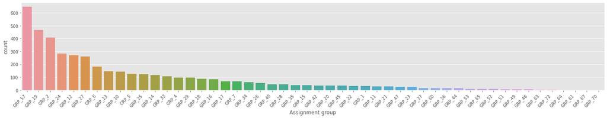

```python
plt.style.use('ggplot')

descending_order = merged_df_temp['Assignment group'].value_counts().sort_values(ascending=False).index
plt.subplots(figsize=(20,4))
ax=sns.countplot(x='Assignment group', data=merged_df_temp,order=descending_order)
ax.set_xticklabels(ax.get_xticklabels(), rotation=45, ha="right")
plt.tight_layout()
plt.show()
```

```python
#Identifying the group with highest datapoints post merge
top_group=merged_df_temp['Assignment group'].value_counts().sort_values(ascending=False).index[0]
print(top_group)
```

```
GRP_57
```

Now we have a view where GRP_57 is having highest number of count. Post merging we have 50 groups excluding GRP_0

# **Data Sampling**

```python
#Initiating sampling with some random state
from sklearn.utils import resample
random_state=123

df_to_upsample = merged_df_temp[merged_df_temp['Assignment group'] != top_group]
df_upsample_high = merged_df_temp[merged_df_temp['Assignment group'] == top_group]
df_to_upsample_temp=merged_df_temp[0:0]
```

```python
#Process to upsample the data
for grp in df_to_upsample['Assignment group'].unique():
    tempGrpDF = merged_df_temp[merged_df_temp['Assignment group'] == grp]
    resampled = resample(tempGrpDF, replace=True, n_samples=len(df_upsample_high), random_state=random_state)
    df_to_upsample_temp = df_to_upsample_temp.append(resampled)
```

```python
df_upsampled = pd.concat([df_upsample_high, df_to_upsample_temp])
df_upsampled.reset_index(inplace=True)
```

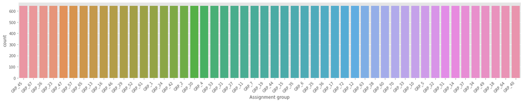

```python
# To visualize the upsampled data
plt.style.use('ggplot')

descending_order = df_upsampled['Assignment group'].value_counts().sort_values(ascending=False).index
plt.subplots(figsize=(20,4))
ax=sns.countplot(x='Assignment group', data=df_upsampled,order=descending_order)
ax.set_xticklabels(ax.get_xticklabels(), rotation=45, ha="right")
plt.tight_layout()
plt.show()
```

Now its evident from above view that all groups (except group0) have the same number of data points post upsampling

```python
#combining the upsampled data with group0 data
df_final = pd.concat([df_upsampled, df_temp[df_temp['Assignment group'] == 'GRP_0']])
```

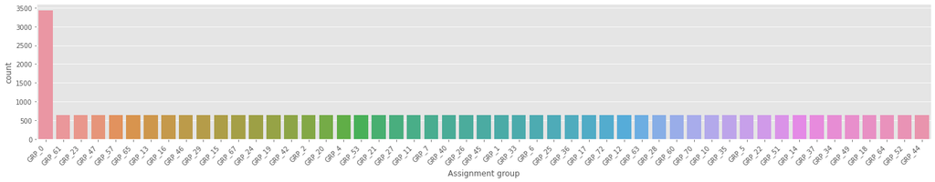

```python
# To visualize the whole (merged) data
plt.style.use('ggplot')

descending_order = df_final['Assignment group'].value_counts().sort_values(ascending=False).index
plt.subplots(figsize=(20,4))
ax=sns.countplot(x='Assignment group', data=df_final,order=descending_order)
ax.set_xticklabels(ax.get_xticklabels(), rotation=45, ha="right")
plt.tight_layout()
plt.show()
```

```python
# initiaing the label encoding for the multi nomial classification ease
from sklearn import preprocessing
def labelencoder(data) :
  label_encoder = preprocessing.LabelEncoder()
  data= label_encoder.fit_transform(data)
  grp_mapping = dict(zip(label_encoder.transform(label_encoder.classes_), label_encoder.classes_))
  return data
```

```python
 y= labelencoder(df_final['Assignment group'])
 X= df_final['Translated_Description']
```

# **Model Building**

```python
#Importing libs for further model building
from sklearn import model_selection,preprocessing,naive_bayes, linear_model, ensemble, metrics, svm
```

```python
#Train Test data split
train_x, valid_x, train_y, valid_y = model_selection.train_test_split(X, y)
```

```python
#Vectorising the data
from sklearn.feature_extraction.text import TfidfVectorizer, CountVectorizer
count_vect = CountVectorizer(analyzer='word', token_pattern=r'\w{1,}')
count_vect.fit(X)

xtrain_count =  count_vect.transform(train_x)
xvalid_count =  count_vect.transform(valid_x)
```

```python
#Defining the function to get the accuracy and F1Score for the model build
def train_model(classifier, feature_vector_train, label, feature_vector_valid):
    classifier.fit(feature_vector_train, label)
    predictions = classifier.predict(feature_vector_valid)
    accuracy = metrics.accuracy_score(predictions, valid_y)
    f1score = metrics.f1_score(predictions, valid_y, average='weighted')

    return accuracy, f1score
```

```python
#Defining the dataframe for collating the Accuracy and F1Score of different models
model_accuracy_df = pd.DataFrame(columns = ['Model','Accuracy', 'F1 Score'])
```

```python
def fnModelAccuracy(name, accuracy, f1score):
  print(name, accuracy, f1score)
  return {'Model':name,'Accuracy':accuracy,'F1 Score':f1score}
```

```python
#Naive Bayes
accuracy, f1score = train_model(naive_bayes.MultinomialNB(), xtrain_count, train_y, xvalid_count)
model_accuracy_df = model_accuracy_df.append(fnModelAccuracy("NB, Count Vectors: ", accuracy, f1score),ignore_index = True)
```

```
NB, Count Vectors:  0.8397802444220204 0.8414384374159987
```

```python
#Logistic Regression
accuracy, f1score = train_model(linear_model.LogisticRegression(), xtrain_count, train_y, xvalid_count)
model_accuracy_df = model_accuracy_df.append(fnModelAccuracy("LR, Count Vectors: ", accuracy, f1score),ignore_index = True)
```

```
LR, Count Vectors:  0.9309339612064133 0.9299623765954466
```

```python
#SVM
accuracy, f1score = train_model(svm.SVC(), xtrain_count, train_y, xvalid_count)
model_accuracy_df = model_accuracy_df.append(fnModelAccuracy("SVM, Count Vectors: ", accuracy, f1score),ignore_index = True)
```

```
SVM, Count Vectors:  0.9163583361363381 0.9172675370978947
```

```python
# RF on Count Vectors
accuracy, f1score = train_model(ensemble.RandomForestClassifier(), xtrain_count, train_y, xvalid_count)
model_accuracy_df = model_accuracy_df.append(fnModelAccuracy("RF, Count Vectors: ", accuracy, f1score),ignore_index = True)
```

```
RF, Count Vectors:  0.9394550958627649 0.9383710619480937
```

```python
#Consolidated metrics of accuracy and F1 score on the different models trained
model_accuracy_df
```

|  | Model | Accuracy | F1 Score |
| --- | --- | --- | --- |
| 0 | NB, Count Vectors: | 0.839780 | 0.841438 |
| 1 | LR, Count Vectors: | 0.930934 | 0.929962 |
| 2 | SVM, Count Vectors: | 0.916358 | 0.917268 |
| 3 | RF, Count Vectors: | 0.939455 | 0.938371 |

So far we have evaluated the four different machine learning models on the preprocessed data. We still need to check on the preformance by tuning the hyperparams for these models and will take up on the Neural network models too. In upcomiing weeks we will also try more of word embeddings to improve the performance.